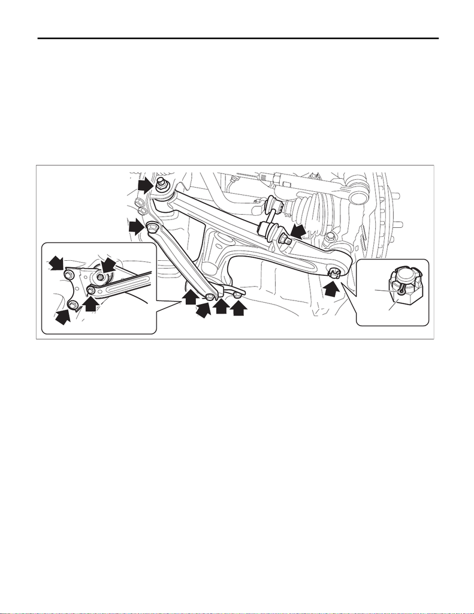

FS-37

Front Arm

FRONT SUSPENSION

7. Front Arm

A: REMOVAL

1) Lift up the vehicle, and then remove the front wheels.

2) Remove the under cover - front. <Ref. to EI-21, REMOVAL, Front Under Cover.>

3) Remove the front arm assembly.

(1) Remove the bolt, and then detach the front support.

(2) Remove the bolts and nuts, and then remove the front arm rear plate.

(3) Remove the nut and disconnect the stabilizer link assembly.

(4) Pull out the cotter pin (a), remove the castle nut (b), and remove the ball joint assembly from front arm

assembly.

(5) Remove the nuts, pull out the flange bolt, and remove the front arm assembly.

FS-00676

(3)

(4)

(1)

(2)

(2)

(2)

(2)

(2)

(1)

(2)

(1)

(5)

(a)

(b)

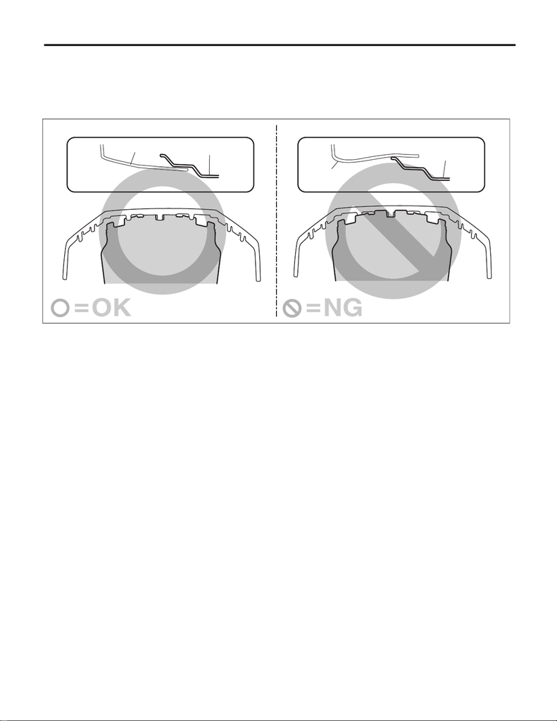

FS-38

Front Arm

FRONT SUSPENSION

B: INSTALLATION

CAUTION:

• For parts which are not reusable, always use new parts.

• Install the under cover - front so that the front end of the under cover (b) comes inside the bumper

face - front (a).

1) Before installation, inspect the following items and replace any faulty part with a new one.

• Check the front arm assembly for damage or cracks, and replace if defective.

• Visually check the bushing for abnormal cracks, fatigue or damage.

• Visually check the dust cover on the ball joint assembly for damage.

2) Using new self-locking nuts and flange bolts, temporarily tighten the front arm assembly to the front cross-

member assembly.

EI-04291

(b)

(a)

(b)

(a)

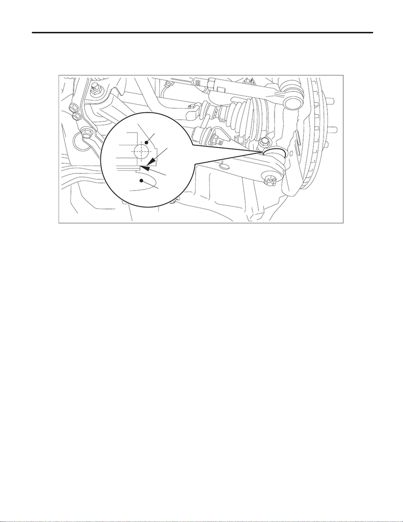

FS-39

Front Arm

FRONT SUSPENSION

3) Connect the front arm assembly to the ball joint assembly.

CAUTION:

Before tightening, make sure the bottom surface of the housing assembly - front axle and the

stepped section of ball joint are in contact.

Tightening torque:

50 N·m (5.1 kgf-m, 36.9 ft-lb)

4) Install the stabilizer link assembly.

Tightening torque:

60 N·m (6.1 kgf-m, 44.3 ft-lb)

5) Install the under cover - front. <Ref. to EI-22, INSTALLATION, Front Under Cover.>

6) Install the front wheels.

Tightening torque:

120 N·m (12.2 kgf-m, 88.5 ft-lb)

7) Unload the vehicle from the lift, and tighten the bolt which secures the front arm assembly to the front

crossmember assembly while the wheels are in full contact with the ground and the vehicle is at curb weight.

Tightening torque:

Refer to “COMPONENT” of “General Description” for the tightening torque. <Ref. to FS-4, FRONT

SUSPENSION, COMPONENT, General Description.>

8) Inspect the wheel alignment and adjust if necessary.

• Inspection: <Ref. to FS-10, INSPECTION, Wheel Alignment.>

• Adjustment: <Ref. to FS-15, ADJUSTMENT, Wheel Alignment.>

CAUTION:

When the wheel alignment has been adjusted, perform “VDC sensor midpoint setting mode” of the

VDC. <Ref. to VDC-16, ADJUSTMENT, VDC Control Module and Hydraulic Control Unit (VDCCM&H/

U).>

9) Perform reinitialization of the auto headlight beam leveler system. (Model with auto headlight beam level-

er) <Ref. to LI-16, PROCEDURE, Auto Headlight Beam Leveler System.>

(a) Bottom surface of housing ASSY -

front axle

(c) Housing ASSY - front axle (d) Ball joint ASSY

FS-00508

(a)

(b)

(c)

(d)

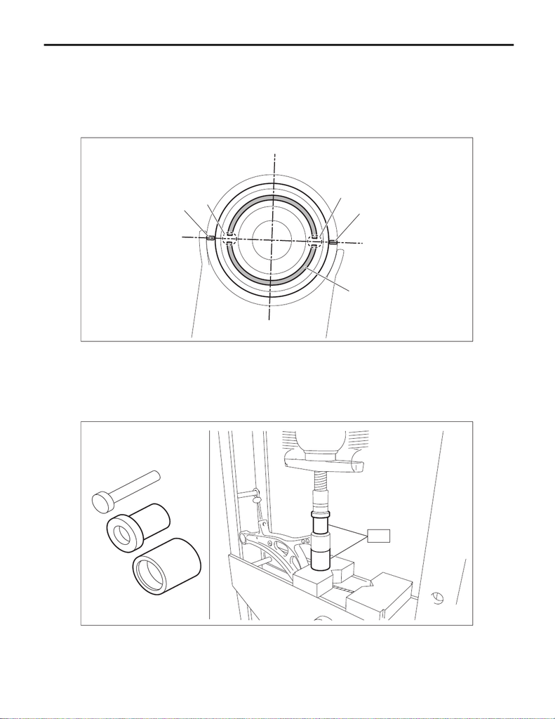

FS-40

Front Arm

FRONT SUSPENSION

C: DISASSEMBLY

1. BUSHING FRONT - FRONT ARM

1) Put an alignment mark on the front arm assembly based on the split portion of the bushing intermediate

plate of the busing front - front arm.

CAUTION:

Always put an alignment mark for aligning the position on bushing installation.

2) Using the ST and a press, remove the busing front - front arm.

Preparation tool:

ST: INSTALLER & REMOVER SET (927680000)

(a) Put an alignment mark. (b) Split portion of bushing intermedi-

ate plate

(c) Bushing intermediate plate

FS-00527

(c)

(a)

(a)

(b)

(b)

FS-00411

ST

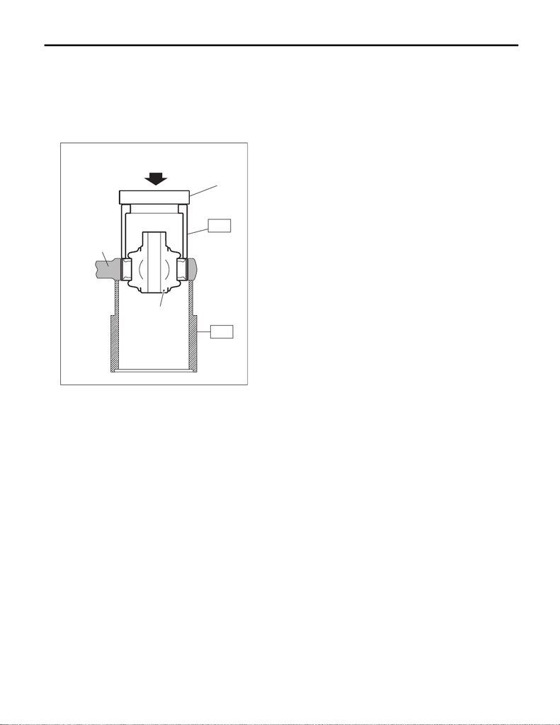

FS-41

Front Arm

FRONT SUSPENSION

2. BUSHING REAR - FRONT ARM

1) Put an alignment mark on the front arm assembly based on the center of recess portion of the busing

rear - front arm.

2) Using the ST and a press, remove the busing rear - front arm.

Preparation tool:

ST1: INSTALLER & REMOVER (20099AE020)

ST2: HOUSING STAND (28099PA010)

NOTE:

Place a metal plate on the ST1 to use the press.

FS-00425

(1)

(2)

(3)

ST2

ST1

(4)

(1) Press

(2) Front arm ASSY

(3) Bushing rear - front arm

(4) Plate

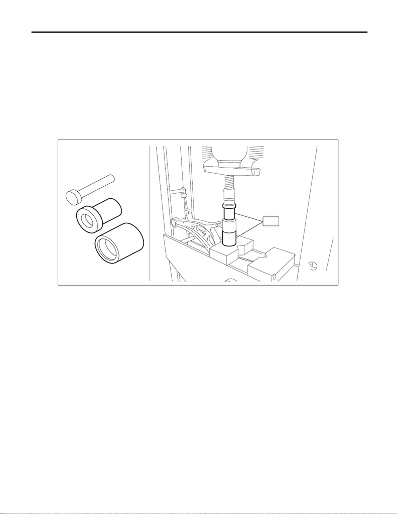

FS-42

Front Arm

FRONT SUSPENSION

D: ASSEMBLY

1. BUSHING FRONT - FRONT ARM

1) Before assembly, inspect the following items and replace any faulty part with a new one.

• Check the front arm assembly for damage or cracks, and replace if defective.

• Visually check the bushing for abnormal cracks, fatigue or damage.

• Visually check the dust cover on the ball joint assembly for damage.

2) Align the alignment mark on the front arm assembly to the split portion of the bushing intermediate plate

of the busing front - front arm.

3) Using the ST and a press, assemble the busing front - front arm.

Preparation tool:

ST: INSTALLER & REMOVER SET (927680000)

FS-00411

ST

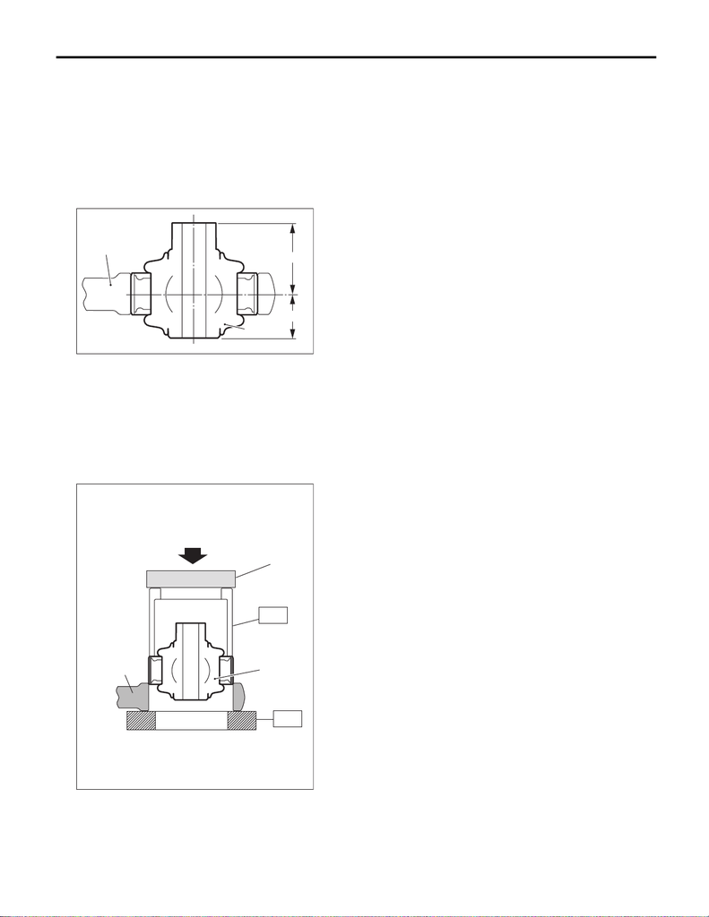

FS-43

Front Arm

FRONT SUSPENSION

2. BUSHING REAR - FRONT ARM

1) Before installation, inspect the following items and replace any faulty part with a new one.

• Check the front arm assembly for damage or cracks, and replace if defective.

• Visually check the bushing for abnormal cracks, fatigue or damage.

• Visually check the dust cover on the ball joint assembly for damage.

2) Using the ST and a press, install the busing rear - front arm.

CAUTION:

Install with the longer inner cylinder of the pillow ball bushing facing upward and the shorter facing

downward.

Preparation tool:

ST1: INSTALLER & REMOVER (20099AE020)

ST2: HOUSING STAND (28099PA010)

FS-00441

(1)

(2)

(3)

(4)

(1) Front arm

(2) Bushing inner cylinder

(3) Longer

(4) Shorter

FS-00426

(1)

(2)

(3)

ST1

(4)

ST2

(1) Press

(2) Front arm ASSY

(3) Bushing rear - front arm

(4) Plate